# assignment06

Elena Bagnera

10/31/2021

## Question 1

RMSE=2.10 MAE=1.6

Because of the squaring, RMSE penalizes large errors more than MSA does.

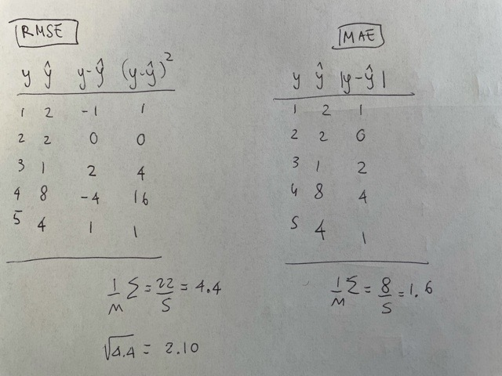

```r
knitr::include_graphics("Images/image0 (1).jpeg")
```

## Question 2

ACCURACY= 70% PRECISION= 75% RECALL/SENSITIVITY= 60%

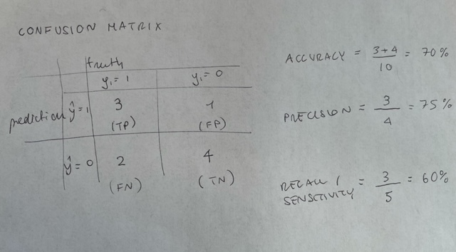

```r
knitr::include_graphics("Images/image2.jpeg")
```

## Question 3

ACCURACY= 67% MISSCLASSIFICATION RATE= 34%

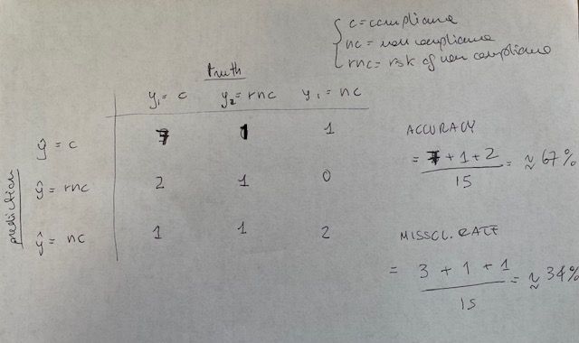

```r
knitr::include_graphics("Images/image3.jpg")
```

## Question 4

*Consider a population where it is known that 0.49 of observations have a value of 0 and 0.51 of observations have a value of 1. Approximately what accuracy can be achieved by simply guessing the same value for all observations? What number should you predict?*

You would get a 51% accuracy if you guess 1 for all observations and 49 if you guess 0. To maximize accuracy, you would predict 1.

*Consider a population where it is known that 0.99 of observations have a value of 0 and 0.01 of observations have a value of 1. Approximately what accuracy can be achieved by simply guessing the same value for all observations? What number should you predict?*

You would get a 1% accuracy if you guess 1 for all observations and 99% if you guess 0. What you want to predict depends on context. If you are maximizing for efficiency though, you should predict 0.

*Explain why it is important to consider context when comparing calculated accuracy in different supervised machine learning tasks?*

Based on your policy goal, false positives, and false negatives carry different costs. This is why it's good to consider other measures other than accuracy, such as sensitivity. In the second case for example, it may be very important to predict the 1 right and not to get a false negative, even if that means having a model that has less accuracy. One solution would be to lower the threshold for predicting a 1.

Another point to notice, is that while the second model is performing significantly better, this is not because it's a better model, but it's because the underlying data is skewed towards 0.

## Question 5

5.1

```r
set.seed(20200229)

marbles <- read_csv("/Users/farahkaddah/Documents/GitHub/assignment06_EB/Data/marbles.csv") # notice I am using farah's laptop due to my issue with R studio so I had to copy the whole path

# creating a split object
marbles_split <- initial_split(data=marbles, prop=0.8)

# create the training and testing data
marbles_train <- training(x = marbles_split)
marbles_test <- testing(x = marbles_split) # putting this to the side

marbles_train_keep <- marbles_train %>%
  mutate(color=as_factor(color)) ## doing this here to keep the original train data for exercise 6
```

5.2

We can use a model that predicts black when we have a large sized ball.

```r
marbles_train <- marbles_train %>%
  count(color, size) %>%
  ggplot(aes(x=size, y=n, fill=color))+
  geom_bar(position = "stack", stat="identity")
```

5.3

```r
predict_marbles <- function(x) {

  marbles_predictions <- case_when(
  x=="big" ~ "black",
  x=="small" ~ "white"
  )

return(marbles_predictions)

}

predict_marbles(x=c("big", "small", "small","big")) #works!
```

```
## [1] "black" "white" "white" "black"
```

```r
marbles_test <- marbles_test %>%
  mutate(y_hat=predict_marbles(size))  # applying the function
```

5.4

```r
accuracy_confusion <- function(color, y_hat) {

  accuracy <- mean(
  color==y_hat
  )

  confusion <-table(
    "pred"=y_hat, "truth"= color
  )

return(list(accuracy, confusion))

}

accuracy_confusion(marbles_test$color, marbles_test$y_hat) #testing the function on the testing dataset
```

```
## [[1]]
## [1] 0.76
##
## [[2]]
##        truth
## pred    black white
##   black    12     5
##   white     1     7
```

```r
#accuracy is 76%
```

5.5

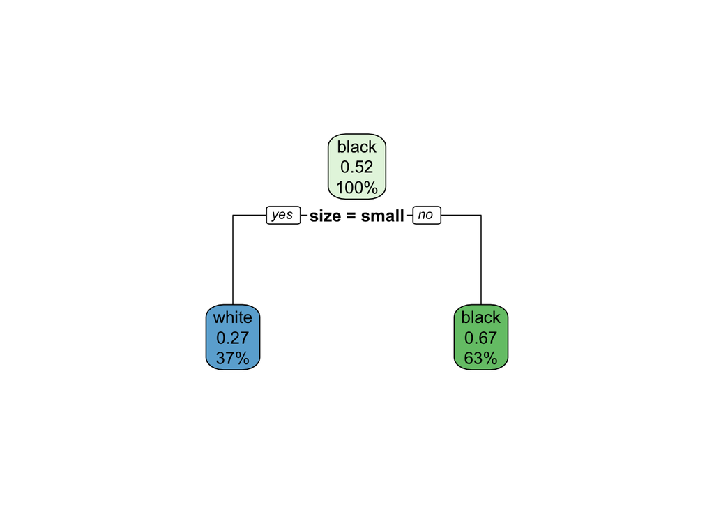

```r
cart_mod <- decision_tree() %>%
  set_engine(engine="rpart") %>%
  set_mode(mode="classification")

cart_fit <- cart_mod %>% #fitting the model
  fit(formula= color ~., data=marbles_train_keep) #using the original train data set where color is a factor

rpart.plot::rpart.plot(x=cart_fit$fit, roundint=TRUE) # creating a tree
```

```r
tree_predictions <- bind_cols(
  marbles_test,
  predict(cart_fit, marbles_test)
) # predicting on the testing dataset

accuracy_confusion(tree_predictions$color, tree_predictions$.pred_class)
```

```
## [[1]]
## [1] 0.76
##
## [[2]]
##        truth
## pred    black white
##   white     1     7
##   black    12     5
```

5.6

The custom function and decision tree are producing the same predictions (they both have 76% accuracy). This is because the tree does the same thing as our instuitive custom function; it predicts color based on the size. The decision tree picked up on the same rule by looking at the data as we did.

## Question 6

```r
# input the data
rats <- tribble(
  ~rat_burrow, ~pizza_distance,
  1, 0.01,
  1, 0.05,
  1, 0.08,
  0, 0.1,
  0, 0.12,
  1, 0.2,
  1, 0.3,
  1, 0.5,
  1, 0.75,
  0, 0.9,
  1, 1,
  0, 1.2,
  0, 2.2,
  0, 2.3,
  0, 2.5,
  1, 3,
  0, 3.5,
  0, 4,
  0, 5,
  0, 7
) %>%
  mutate(rat_burrow = factor(rat_burrow))

# split into training and testing data
split <- initial_split(rats, prop = 0.75)

rats_training <- training(split)

rats_testing <- testing(split)

rats_k1 <- vfold_cv(data = rats_training,
                    v = 3) #a resample with three folds

rats_k3 <- vfold_cv(data = rats_training,
                    v = 3)

rats_kn <- vfold_cv(data = rats_training,
                    v = 3)
```

```r
analysis(rats_k1$splits[[1]]) # this is for testing
```

```
## # A tibble: 10 × 2
##    rat_burrow pizza_distance
##    <fct>               <dbl>
##  1 0                    4
##  2 0                    1.2
##  3 0                    0.12
##  4 0                    2.5
##  5 0                    0.9
##  6 0                    3.5
##  7 0                    5
##  8 1                    0.05
##  9 1                    0.3
## 10 1                    0.01
```

```r
assessment(rats_k1$splits[[1]]) # this is for training
```

```
## # A tibble: 5 × 2
##   rat_burrow pizza_distance
##   <fct>               <dbl>
## 1 0                    0.1
## 2 0                    7
## 3 1                    0.5
## 4 1                    0.08
## 5 1                    3
```

```r
predictions_k1 <- data.frame(y_hat=c(0, 0, 1, 0, 0)) # calculating y hat by hand by looking at the closest x in the analysis data

rats_k1_assessment <- bind_cols(
  assessment(rats_k1$splits[[1]]),
  predictions_k1
)

knitr::kable(rats_k1_assessment) #generating a table
```

| rat_burrow | pizza_distance | y_hat |
| --- | --- | --- |
| 0 | 0.10 | 0 |
| 0 | 7.00 | 0 |
| 1 | 0.50 | 1 |
| 1 | 0.08 | 0 |
| 1 | 3.00 | 0 |

```r
accuracy_confusion(rats_k1_assessment$rat_burrow, rats_k1_assessment$y_hat) # 60% accuracy
```

```
## [[1]]
## [1] 0.6
##
## [[2]]
##     truth
## pred 0 1
##    0 2 2
##    1 0 1
```

```r
analysis(rats_k3$splits[[1]]) # this is for testing
```

```
## # A tibble: 10 × 2
##    rat_burrow pizza_distance
##    <fct>               <dbl>
##  1 0                    4
##  2 0                    7
##  3 0                    1.2
##  4 1                    0.5
##  5 0                    2.5
##  6 1                    0.08
##  7 0                    5
##  8 1                    0.3
##  9 1                    0.01
## 10 1                    3
```

```r
assessment(rats_k3$splits[[1]]) # this is for training
```

```
## # A tibble: 5 × 2
##   rat_burrow pizza_distance
##   <fct>               <dbl>
## 1 0                    0.1
## 2 0                    0.12
## 3 0                    0.9
## 4 0                    3.5
## 5 1                    0.05
```

```r
predictions_k3 <- data.frame(y_hat=c(1, 1, 1, 0, 1))


rats_k3_assessment <- bind_cols(
  assessment(rats_k3$splits[[1]]),
  predictions_k3
)

knitr::kable(rats_k3_assessment) #generating a table
```

| rat_burrow | pizza_distance | y_hat |
| --- | --- | --- |
| 0 | 0.10 | 1 |
| 0 | 0.12 | 1 |
| 0 | 0.90 | 1 |
| 0 | 3.50 | 0 |
| 1 | 0.05 | 1 |

```r
accuracy_confusion(rats_k3_assessment$rat_burrow, rats_k3_assessment$y_hat) # 40% accuracy
```

```
## [[1]]
## [1] 0.4
##
## [[2]]
##     truth
## pred 0 1
##    0 1 0
##    1 3 1
```

```r
analysis(rats_kn$splits[[1]]) # this is for testing
```

```
## # A tibble: 10 × 2
##    rat_burrow pizza_distance
##    <fct>               <dbl>
##  1 0                    4
##  2 0                    7
##  3 0                    1.2
##  4 0                    0.12
##  5 1                    0.5
##  6 0                    2.5
##  7 1                    0.08
##  8 0                    3.5
##  9 0                    5
## 10 1                    0.05
```

```r
assessment(rats_kn$splits[[1]]) # this is for training
```

```
## # A tibble: 5 × 2
##   rat_burrow pizza_distance
##   <fct>               <dbl>
## 1 0                    0.1
## 2 0                    0.9
## 3 1                    0.3
## 4 1                    0.01
## 5 1                    3
```

```r
predictions_kn <- data.frame(y_hat=c(0, 0, 0, 0, 0)) #calculating Y hat by hand with k=10

rats_kn_assessment <- bind_cols(
  assessment(rats_kn$splits[[1]]),
  predictions_kn
)

knitr::kable(rats_kn_assessment) #generating a table
```

| rat_burrow | pizza_distance | y_hat |
| --- | --- | --- |
| 0 | 0.10 | 0 |
| 0 | 0.90 | 0 |
| 1 | 0.30 | 0 |
| 1 | 0.01 | 0 |
| 1 | 3.00 | 0 |

```r
accuracy_confusion(rats_kn_assessment$rat_burrow, rats_kn_assessment$y_hat) # 40% accuracy
```

```
## [[1]]
## [1] 0.4
##
## [[2]]
##     truth
## pred 0 1
##    0 2 3
```

The last was the easiest the compute because we were just taking the mode. The hardest was probably the second one, with k=3, since we had to look across the predictions of 3 observations and take the mode out of those.